# Data Science Fundamentals in R

Phil Chodrow, MIT

Tuesday, August 27th, 2019

# Introduction

- The Circle of Data Science
- The Tidyverse
- The Data

## Data Science Is:

- Gathering **data that matters.**
- Asking **questions that matter** about your data.
- **Choosing appropriate methods** to answer those questions.
- **Implementing solutions** that meets stakeholder needs.

## My Favorite Picture

[figure not shown]

## My Favorite Picture

[figure not shown]

- **Exploratory data analysis (EDA)** covers roughly the “transform” and “visualize” steps.

## EDA is getting to know your Data

[figure not shown]

## The Data

[figure not shown]

## The Data

- Scraped by [InsideAirBnB](http://insideairbnb.com/), “an independent, non-commercial set of tools and data that allows you to explore how Airbnb is really being used in cities around the world.”
- Includes `listings` info, a `calendar` of prices, and texts of `reviews`. We’ll be using the first two data sets today.
- Data given for mid-2019 through mid-2020 (for prices and availability).

# Fundamentals of Exploratory Data Analysis

1. Reading and inspecting data.
2. The pipe operator.
3. Data wrangling.

## Pipes for your Data

[figure not shown]

## Pipes for your Data

[figure not shown]

- `x %>% f()` $\Longleftrightarrow$ `f(x)`
- *“Take `x`, and **then** do `f` to it”*
- `x %>% f(y)` $\Longleftrightarrow$ `f(x,y)`
- `x %>% f(y) %>% g(z)` $\Longleftrightarrow$ `g(f(x,y),z)`
- *“Take `x`, **then** do `f` with option `y`, **then** do `g` with option `z`…”*

## Exercises and Examples

```r
listings %>% glimpse()  # = glimpse(listings)
listings %>% head()     # = head(listings)
listings %>% colnames() # = colnames(listings)

listings %>%
    select(contains('review_scores'))  # what does this do?

listings %>%
    select(contains('review_scores')) %>%  # what about this?
    colnames()
```

Ok, back to the script to put this in action.

# Data Visualization

1. Graphical Excellence
2. The Grammar of Graphics
3. `ggplot2`

## Graphical Excellence

[figure not shown]

## Graphical Excellence

> Graphical excellence is the **well-designed presentation of interesting data** – a matter of substance, of statistics, and of design. Graphical excellence consists of complex ideas communicated with **clarity**, **precision**, and **efficiency**.

– *Edward Tufte*

## Graphical Excellence ([edwardtufte.com](https://www.edwardtufte.com/bboard/images/0003Cs-8047.GIF))

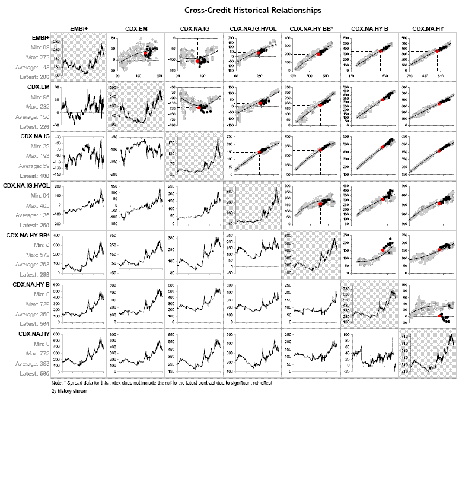

## The Grammar of Graphics

A **grammar** is a set of components (ingredients) that you can combine to create complex structures (sentences, recipes, data visualizations). In baking….

- **A body** – typically some kind of flour)
- **Binder** – eggs, oil, butter, applesauce
- **A rising agent** – yeast, baking soda, baking powder
- **Flavoring** – sugar, salt, chocolate, vanilla
- Get it wrong, and…

[figure not shown]

## The Grammar of Graphics

- Puts the `gg` in `ggplot2`.
- Formulated by Leland Wilkinson.
- Implemented in code by Hadley Wickham, now part of the `tidyverse`

[figure not shown]

[figure not shown]

## Ingredients of a data visualization

- **`Data`**: almost always a `data_frame`
- **`Aes`**thetic mapping: relation of data to chart components.
- **`Geom`**etry: specific visualization type? E.g. line, bar, heatmap?
- **`Stat`**istical transformation: how should the data be transformed or aggregated before visualizing?
- **`Theme`**: how should the non-data parts of the plot look?
- Misc. other options.
- (`+` plays the same role in `ggplot2` that `%>%` does in data manipulation.)

# Literate Programming with R Markdown

## Literate Programming

The idea of *literate programming* is to collect your code, outputs, and explanatory narrative in a single, convenient document that can meet the needs of multiple stakeholders.

## R Markdown

- [R Markdown](https://rmarkdown.rstudio.com) is an authoring format for creating attractive documents, slides, websites, and more using `R`.
- These slides are written in RMarkdown ([source here](https://philchodrow.github.io/mban_orientation/1_orientation/2_data_science/index.html)).
- We are going to take a quick tour of R Markdown features before jumping into your mini-project for today.

# Mini-Project

## The Setup

- You are a seasoned data scientist who has just arrived in Boston.
- You’re want to go see the sights, but you don’t know where they are!
- Instead of buying a tourist guide like a Muggle would, you are going to use your skills in exploratory data analysis to find cool spots to visit.

## What You’ll Make

Like [this](https://philchodrow.github.io/mban_orientation/1_orientation/2_data_science/code/dashboard.html), but way better.

## Instructions

- Your **deliverable** is `dashboard.rmd`, which you can find in the `1_orientation/2_data_science/code` directory. You should have checked that this `knit` correctly in the preassignment.
- Personalize the dashboard with your name and your partner’s name.
- Conduct analysis to identify **three** locations or neighborhoods you want to visit. Use Google to figure out what might be interesting about those spots, but your commentary should show how your analysis supports your findings.
- At the end of the hour, you will upload `dashboard.html` at the provided link.

# Additional Resources

## Guides and Cheatsheets

- Data Wrangling [Cheatsheet](https://www.rstudio.com/wp-content/uploads/2015/02/data-wrangling-cheatsheet.pdf)
- `ggplot2` [Cheatsheet](https://www.rstudio.com/wp-content/uploads/2015/03/ggplot2-cheatsheet.pdf)
- [The `R` Graphics Cookbook](http://www.cookbook-r.com/Graphs/), by Winston Chang

## Books and Courses

- Jenny Bryan’s fabulous [course website](http://stat545.com/) on introductory, reproducible data analysis with `R`
- [R for Data Science](http://r4ds.had.co.nz/), a book on the Tidyverse by Hadley Wickham and Garrett Grolemund
- Modules 2-4 of [“Computing in Optimization and Statistics”](https://philchodrow.github.io/cos_2018/) (15.S60) covers similar material in more breadth and depth.

## Other Topics in `R`

- [Reproducible research](https://simplystatistics.org/2015/12/11/instead-of-research-on-reproducibility-just-do-reproducible-research/) with [RMarkdown](http://rmarkdown.rstudio.com/)
- Interactive data applications with [Shiny](https://shiny.rstudio.com/)
- Automate long data science pipelines with GNU [make](http://stat545.com/automation04_make-activity.html)
- Develop your own `R` [packages](http://r-pkgs.had.co.nz/)
- Some news on [`R`](https://www.r-bloggers.com/), [statistics](https://simplystatistics.org/), and [data science at FiveThirtyEight](http://fivethirtyeight.com/) (they use `R`!)

## Some Cool `R` Tricks

- [Literate Documents](http://timelyportfolio.github.io/rCharts_nyt_home_price/)
- [Interactive Dashboards](http://jkunst.com/flexdashboard-highcharter-examples/pokemon/) with Shiny
- [Blogs and Websites](https://philchodrow.com)
- These [slides](http://rmarkdown.rstudio.com/ioslides_presentation_format.html) are written in `R`